# Analysis of Batch Effects

Kenyon

April 12, 2016

In this file, the RNAseq data is analyzed for batch effects between biological replicates. The data are the 21 samples of DSM-grown LiaS-McpA-NhaK set of mutants, harvested in late-exponential phase growth. (Batch effect analysis begins on line 126)

### 1. Import Data, Libraries, and Functions

```r
#Gene expression data:
gtab<-read.csv("~/Bacillus_subtilis/RNAseq/Rockhopper_results2/NC_000964_transcripts_rawcounts_forDSEQ2.csv", row.names=1)

#sample table:
samp3<- read.csv("~/Bacillus_subtilis/RNAseq/Rockhopper_results2/Index_sheet-samplesums-Rockhopper2-b.csv", row.names=1)

#Gene annotation file:
gdf<-read.csv("~/Bacillus_subtilis/RNAseq/Bsub_annotation/Bsub_Functional_Annotation_2016-04-12.csv",row.names=1)

gdf$ME_name<-as.character(gdf$ME_name)
gdf$ME_name <- sub("^$", "nonphage", gdf$ME_name)
gdf$ME_name<-as.factor(gdf$ME_name)

# Modify samp3: convert some columns to factors and establish strain order levels
samp3$GR_column<-as.factor(as.character(samp3$GR_Column))
samp3$strain<-as.factor(as.character(samp3$strain))
samp3$strain<-factor(samp3$strain,levels=c("AM373","LiaS","McpA","NhaK","LM","LN","MN"))
samp3$date<-as.factor(as.character(samp3$date))

#Modify gtab3: remove confounding and low-count genes
#remove rrn genes from gene expression data
rrn_rows<-which(substring(row.names(gtab),1,3)=="rrn")
gtab2<-gtab[-rrn_rows,]

#remove low-count genes, threshold of at least 50 counts between all samples
gtab3 <- gtab2[ rowSums(gtab2) > 50, ]
```

Number of rRNA genes: 30 genes dropped (from 4849)

Number of genes with <50 counts: 207 genes dropped

Note about file gdf: While looking up the genes indivdiually, I also noticed that many of the DEGs belong to mobile genetic element [ICEBs1](http://www.ncbi.nlm.nih.gov/pubmed/17511812); however, these genes are not included in any of the annotation, so I created two new columns, `Phage_ME` and `ME_name` to encode it; `ME_name` encodes either the name of the phage/mobile element or “nonphage”

Libraries used:

```r
library(DESeq2)
library(dplyr)
library(knitr)
library(ggplot2)
```

#### Useful Functions

Load function`top_genes` to make a results table, order and filter the genes by padj, and add basic annotation from file `gdf`

basic “Functional” annotation in `gdf` is from [subtiwiki](http://subtiwiki.uni-goettingen.de/wiki/index.php/Categories), flatfile downloaded 7/17/2015

```r
source('~/Bacillus_subtilis/RNAseq/RNAseq_to_Github/top_genes_function.R')
```

Functional Annotation Table generator function: `factor_tab(tg_df, factor_name)` creates table of in “FunctNameX” columns of DE gene table to show what functions are highly represented, and the total number of genes in that functional classification set for the whole genome (not quite a statistically-rigorous functional enrichment analysis yet)

```r
source('~/Bacillus_subtilis/RNAseq/RNAseq_to_Github/factor_tab_function.R')
```

ktab function: formats and reorginizes results dataframe into a cleaner “kable” table  
(coded within this document but not printed out)

### 2. Run DESEQ2

```r
#generate DESeqData object
  # design takes into account date (RNAseq batch) and strain identity
ddsBsub<-DESeqDataSetFromMatrix(countData = gtab3,colData = samp3,design= ~date+strain)

#run DESeq on object
ds<-DESeq(ddsBsub)
res<-results(ds)  #to generate a 'results' table from the DESeqDataSet object 'ds'

#rlog trans
rld<-rlog(ddsBsub,blind=FALSE)

#estimate size factors
dds<-estimateSizeFactors(ddsBsub)
```

### 3. Batch Effects

**DESeq2 QC analysis showed some batch effects in data; can now explore what genes are responsible and their functional groups**

Known differences between batches: Samples were grown in a 96-well plate reader that recorded the growth curves and OD at sample collection, permitting comparison of the max growth rate and final OD of the sequenced samples by batch.

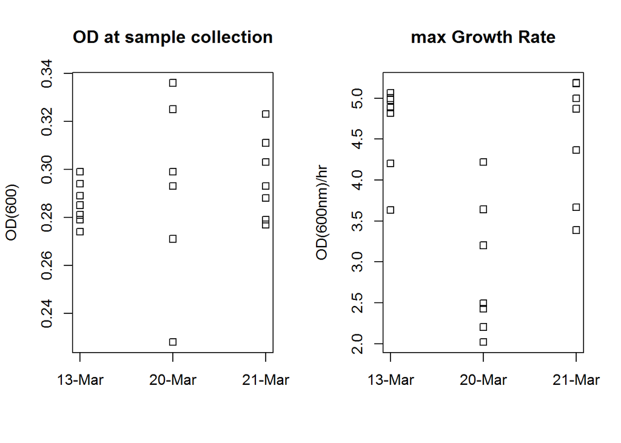

```r
par(mfrow=c(1,2))

stripchart(samp3$avg_OD~samp3$date,vertical=TRUE,ylab="OD(600)",main="OD at sample collection")
stripchart(samp3$avgVmax~samp3$date,vertical=TRUE,ylab="OD(600nm)/hr",main="max Growth Rate")
```

- 20-Mar batch was collected over a wider OD range than the others
- 20-Mar batch also acheived somewhat lower maxGR

#### 3.1 Principle Component Analysis

Plot of PC1 vs PC2 shows:  
* batch “Mar21” is largely on the upper range of PC1 compared to most other measures, while the 3 liaS-deletion strains compose the lower-most range of PC1  
* batch “20-Mar” is clustered on upper range of PC2

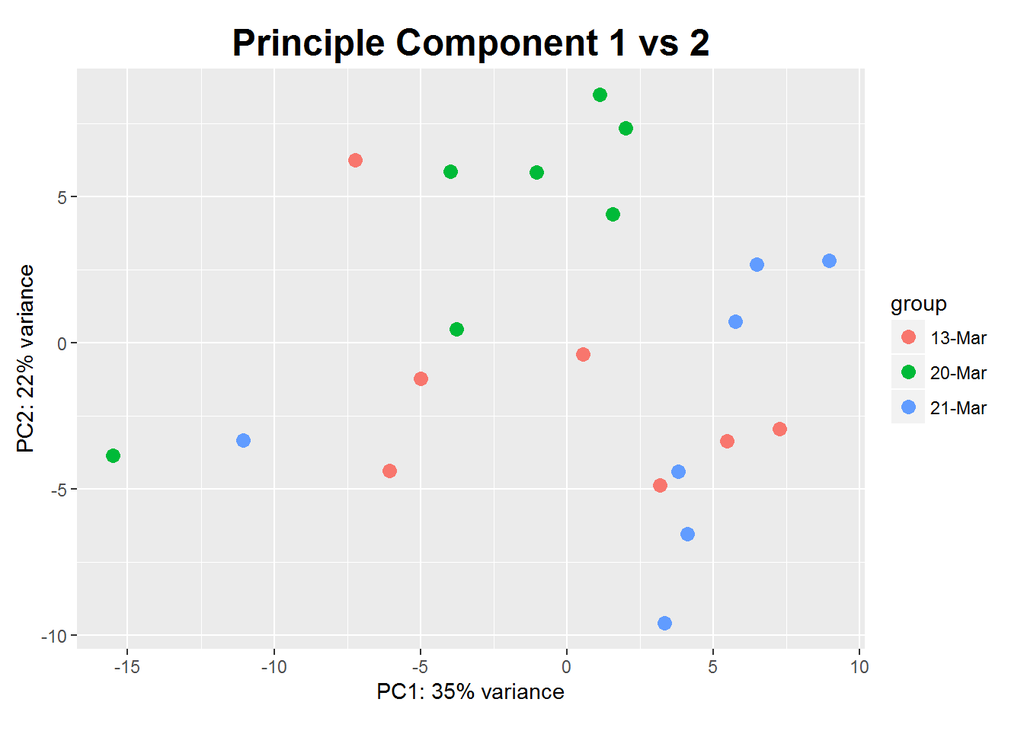

#### Contrast 1: 21-Mar vs other batches

DESEQ analysis using batch at factor, by creating a factor that distinguishes “21-Mar” batch from the other two

```r
isMar21<-relevel(as.factor(ifelse(samp3$date=="21-Mar","21-Mar","other")),ref="other")

sampb1<-cbind(samp3,isMar21)
resb1<-results(DESeq(DESeqDataSetFromMatrix(countData = gtab3,colData = sampb1,design= ~strain+isMar21)))
B1<-top_genes(resb1,num=length(which(resb1$padj<0.05)))
```

```
## [1] "226 genes found with padj<0.05"
```

Top 5 differentially-expressed genes (based lowest p-adjusted value):

|  | Locus.tag | Protein.name | FuncName1 | FuncName2 | FuncName3 | FuncName4 | GoH.sum | ME_name | log10.padj | log2FoldChange | baseMean |
| --- | --- | --- | --- | --- | --- | --- | --- | --- | --- | --- | --- |
| pred_RNA_26522bp_r | NA | downstrm_tadA: opp_strnd | pred_RNA | pred_RNA | pred_RNA | pred_RNA | NA | NA | -12.0 | -1.20 | 636 |
| pred_RNA_3879807bp | NA | within_rocA: opp_strand | pred_RNA | pred_RNA | pred_RNA | pred_RNA | NA | NA | -9.9 | -1.00 | 61 |
| pred_RNA_650171bp_r | NA | within_groES: opp_strand | pred_RNA | pred_RNA | pred_RNA | pred_RNA | NA | NA | -8.9 | -0.81 | 90 |
| pred_RNA_2331535bp | NA | upstrm_ypsB: opp_strand difexp BSU22180 | pred_RNA | pred_RNA | pred_RNA | pred_RNA | NA | NA | -7.7 | -1.00 | 97 |
| rimI | BSU05930 | ribosomal-protein-alanine acetyltransferase | Information processing | protein synthesis, modification and degradation | translation | translation/ other/ based on similarity | NA | nonphage | -7.7 | -0.80 | 404 |

- top_genes function selects genes from the DESeq analysis with differential expression above a significance threshold (padj<0.05 here), and also adds several columns of functional annotation to each gene.
  - The four **“FuncName”** columns refer to annotation available from subtiwiki.org; the gdf-file also has GO annotation, but for this analysis the subtiwiki annotation was easier to work with.
  - **ME_name** describes whether the gene is associated with a mobile element or transposon
  - for **predicted RNAs**, the closest gene is reported, whether the RNA is encoded within the gene or up- or downstream of it, and which strand it is on relative to this gene. If the gene is also differentially expressed in the given contrast, “diffExpr” + BSU# of the gene is also printed. (Further improvements of this analysis could include adding whether both the gene and pred_RNA change expression in the same direction)
- the most drastically changed transcripts in this contrast are mostly predicted_RNAs

**Table of DEGs (differentially-expressed genes) based on their level-1 Functions:**

DEGs: Number of differentially expressed genes all_in_cat: total number of genes in genome in this catagory perc: the percentage of genes in this category that were dif. expressed Up/Dwn: Number of DEGs in category that had increased or decreased expression relative to the reference level

```r
factor_tab(B1,"FuncName1")
```

```
##                               FuncName1 DEGs all_in_cat    perc Up Dwn
## 1                            Metabolism   28        831 0.03370 21   7
## 2                    Cellular processes   21        640 0.03280 16   5
## 3                       Groups of genes   26       1011 0.02570 16  10
## 4                Information processing   14        748 0.01870  6   8
## 5                            Lifestyles   11        694 0.01590  7   4
## 6 Prophages and mobile genetic elements    2        251 0.00797  2   0
## 7                              pred_RNA  119         NA      NA  3 116
## 8                         no assignment    5         NA      NA NA  NA
```

- over half of the Differentially Expressed Genes (DEGs) are pred_RNAs, and almost all of them are downreguated
- metabolism and cell process DEGs are also generally more upregulated

Functional group, level 2:

```
##                                            FuncName2 DEGs all_in_cat    perc Up Dwn
## 1                      RNA synthesis and degradation    3         53 0.05660  2   1
## 2                    amino acid/ nitrogen metabolism   10        179 0.05590  7   3
## 3               electron transport and ATP synthesis    5         93 0.05380  4   1
## 4                                   lipid metabolism    3         69 0.04350  0   3
## 5                    cell envelope and cell division    8        186 0.04300  5   3
## 6                                 coping with stress    9        226 0.03980  7   2
## 7                      additional metabolic pathways    7        202 0.03470  7   0
## 8                                       transporters   13        430 0.03020 11   2
## 9                       proteins of unknown function   20        670 0.02990 13   7
## 10            poorly characterized/ putative enzymes    4        135 0.02960  2   2
## 11   protein synthesis, modification and degradation    6        320 0.01880  1   5
## 12                                          genetics    3        171 0.01750  2   1
## 13                                 carbon metabolism    3        199 0.01510  3   0
## 14 exponential and early post-exponential lifestyles    1         81 0.01230  0   1
## 15                                 membrane proteins    2        182 0.01100  1   1
## 16                     regulation of gene expression    2        204 0.00980  1   1
## 17                                         prophages    2        243 0.00823  2   0
## 18                                       sporulation    1        378 0.00265  0   1
## 19                                          pred_RNA  119         NA      NA  3 116
## 20                                     no assignment    5         NA      NA NA  NA
```

*GoH genes in set:*

- The deleted genes were selected because they are all connected to the GoH protein interaction network
- In this analysis, examine how many other GoH-associated genes and identified hub proteins have differential expressed based on this contrast, encoded by the GoH.sum column (in top_gene-produced files)
- GoH.sum column entry “GoH gene 3 cssS” means:
  - it is a gene profiled in the GoH network, but it is not a Hub,
  - it interacts with 3 other GoH proteins,
  - including target gene cssS (cssS not part of this set of deletion strains though)

|  | Locus.tag | Protein.name | FuncName1 | FuncName2 | FuncName3 | FuncName4 | GoH.sum | ME_name | log10.padj | log2FoldChange | baseMean |
| --- | --- | --- | --- | --- | --- | --- | --- | --- | --- | --- | --- |
| albF | BSU37420 | zinc protease AlbF | Metabolism | additional metabolic pathways | miscellaneous metabolic pathways | biosynthesis of antibacterial compounds | GoH gene, 6 genes | nonphage | -1.7 | 0.58 | 141 |
| ydbI | BSU04480 | hypothetical protein BSU04480 | Groups of genes | membrane proteins | NA | NA | GoH Hub, 10 genes | nonphage | -1.6 | -0.30 | 766 |
| ptsH | BSU13900 | phosphocarrier protein HPr | Cellular processes | transporters | phosphotransferase systems | NA | GoH gene, 1 genes | nonphage | -1.4 | 0.23 | 6660 |

- num of GoH hub proteins: 1
  - [ydbI](http://subtiwiki.uni-goettingen.de/bank/index.php?gene=BSU04480&action=Go) - Unknown function, slightly downregulated
- num of GoH genes: 2
  - though none are directly connected to any of the three deleted target genes
  - both are related to metabolism, and have increased expression in the 21-Mar batch
  - should explore their secondary connectivity to any deleted target genes in a later analysis

Same as above, but contrasting 20-Mar samples vs. the other two batches

```r
isMar20<-relevel(as.factor(ifelse(samp3$date=="20-Mar","20-Mar","other")),ref="other")

sampc1<-cbind(samp3,isMar20)
resc1<-results(DESeq(DESeqDataSetFromMatrix(countData = gtab3,colData = sampc1,design= ~strain+isMar20)))
C1<-top_genes(resc1,num=length(which(resc1$padj<0.05)))
```

```
## [1] "669 genes found with padj<0.05"
```

Top 5 DEGs:

|  | Locus.tag | Protein.name | FuncName1 | FuncName2 | FuncName3 | FuncName4 | GoH.sum | ME_name | log10.padj | log2FoldChange | baseMean |
| --- | --- | --- | --- | --- | --- | --- | --- | --- | --- | --- | --- |
| pred_RNA_647848bp_r | NA | within_tatAY: opp_strand difexp BSU05980 | pred_RNA | pred_RNA | pred_RNA | pred_RNA | NA | NA | -7.0 | 1.40 | 111 |
| yloN | BSU15750 | dual-specificity RNA methyltransferase RlmN | Information processing | protein synthesis, modification and degradation | translation | rRNA modification and maturation/ based on similarity | NA | nonphage | -6.6 | -0.26 | 1314 |
| yneK | BSU17960 | hypothetical protein BSU17960 | Groups of genes | membrane proteins | NA | NA | NA | nonphage | -6.6 | 0.42 | 794 |
| pred_RNA_2797114bp | NA | within_yrzB: opp_strand difexp BSU27380 | pred_RNA | pred_RNA | pred_RNA | pred_RNA | NA | NA | -6.3 | 1.20 | 86 |
| trnI-Thr | NA | NA | NA | NA | NA | NA | NA | NA | -6.2 | 0.73 | 48 |

Functional groups of DEGs:

```r
factor_tab(C1,"FuncName1")
```

```
##                               FuncName1 DEGs all_in_cat   perc Up Dwn
## 1                            Metabolism  165        831 0.1990 24 141
## 2                       Groups of genes  142       1011 0.1400 69  73
## 3                    Cellular processes   83        640 0.1300 18  65
## 4                Information processing   72        748 0.0963 32  40
## 5                            Lifestyles   51        694 0.0735 32  19
## 6 Prophages and mobile genetic elements   10        251 0.0398  5   5
## 7                              pred_RNA  106         NA     NA 93  13
## 8                         no assignment   40         NA     NA NA  NA
```

- 20% of metabolic genes have differential expression, most of them down!

Functional Level 2 categories:

within “Metabolism” FuncName1 category:

```r
factor_tab(C1[which(C1$FuncName1=="Metabolism"),],"FuncName2")
```

```
##                              FuncName2 DEGs all_in_cat  perc Up Dwn
## 1      amino acid/ nitrogen metabolism   59        179 0.330  2  57
## 2        additional metabolic pathways   40        202 0.198  4  36
## 3                nucleotide metabolism   16         89 0.180 12   4
## 4 electron transport and ATP synthesis   14         93 0.151  2  12
## 5                    carbon metabolism   27        199 0.136  2  25
## 6                     lipid metabolism    9         69 0.130  2   7
```

*see that within metabolism, almost all classes are generally less expressed in the Mar-20 batch - except nucleotide metabolism, which has increased transcription

..other FuncName2 catagories:

```r
factor_tab(C1[-which(C1$FuncName1=="Metabolism"),],"FuncName2")
```

```
##                                            FuncName2 DEGs all_in_cat   perc Up Dwn
## 1                               GTP-binding proteins    1          3 0.3330  1   0
## 2             poorly characterized/ putative enzymes   30        135 0.2220  9  21
## 3                            mobile genetic elements    1          5 0.2000  0   1
## 4                      RNA synthesis and degradation   10         53 0.1890  4   6
## 5                                    essential genes    1          6 0.1670  0   1
## 6                                 coping with stress   34        226 0.1500 23  11
## 7                                       transporters   60        430 0.1400 12  48
## 8                       proteins of unknown function   89        670 0.1330 43  46
## 9                                  membrane proteins   21        182 0.1150 16   5
## 10                   cell envelope and cell division   21        186 0.1130  5  16
## 11                         lifestyles/ miscellaneous    1          9 0.1110  1   0
## 12   protein synthesis, modification and degradation   35        320 0.1090 20  15
## 13                                       homeostasis    2         24 0.0833  1   1
## 14                     regulation of gene expression   15        204 0.0735  3  12
## 15                                          genetics   12        171 0.0702  5   7
## 16 exponential and early post-exponential lifestyles    5         81 0.0617  2   3
## 17                                         prophages    9        243 0.0370  5   4
## 18                                       sporulation   11        378 0.0291  6   5
## 25                                          pred_RNA  106         NA     NA 93  13
## 26                                     no assignment   40         NA     NA NA  NA
```

**GoH analysis:**

|  | Locus.tag | Protein.name | FuncName1 | FuncName2 | FuncName3 | FuncName4 | GoH.sum | ME_name | log10.padj | log2FoldChange | baseMean |
| --- | --- | --- | --- | --- | --- | --- | --- | --- | --- | --- | --- |
| ydbI | BSU04480 | hypothetical protein BSU04480 | Groups of genes | membrane proteins | NA | NA | GoH Hub, 10 genes | nonphage | -3.8 | 0.35 | 766 |
| ftsW | BSU14850 | lipid II flippase FtsW | Cellular processes | cell envelope and cell division | cell division | NA | GoH gene, 5 genes | nonphage | -2.9 | -0.25 | 1162 |
| argD | BSU11220 | acetylornithine aminotransferase | Metabolism | amino acid/ nitrogen metabolism | biosynthesis/ acquisition of amino acids | biosynthesis/ acquisition of arginine | GoH gene, 1 genes | nonphage | -2.1 | -0.71 | 46 |
| menA | BSU38490 | 1,4-dihydroxy-2-naphthoate octaprenyltransferase | Metabolism | additional metabolic pathways | biosynthesis of cofactors | biosynthesis of menaquinone | GoH gene, 1 genes | nonphage | -2.1 | 0.26 | 1493 |
| divIB | BSU15240 | cell division protein DivIB | Cellular processes | cell envelope and cell division | cell division | NA | GoH gene, 9 genes- cssS | nonphage | -1.7 | 0.28 | 1138 |
| pksJ | BSU17180 | polyketide synthase PksJ | Metabolism | additional metabolic pathways | miscellaneous metabolic pathways | biosynthesis of antibacterial compounds | GoH gene, 6 genes- cssS | nonphage | -1.6 | -0.45 | 7915 |
| ptsH | BSU13900 | phosphocarrier protein HPr | Cellular processes | transporters | phosphotransferase systems | NA | GoH gene, 1 genes | nonphage | -1.6 | -0.22 | 6660 |
| yczI | BSU04120 | hypothetical protein BSU04120 | Groups of genes | membrane proteins | NA | NA | GoH gene, 6 genes | nonphage | -1.5 | 0.42 | 105 |
| yvcB | BSU34840 | hypothetical protein BSU34840 | Groups of genes | proteins of unknown function | NA | NA | GoH gene, 1 genes | nonphage | -1.5 | 0.28 | 6237 |
| yvcD | BSU34810 | TPR repeat-containing protein YvcD | Groups of genes | proteins of unknown function | NA | NA | GoH gene, 1 genes | nonphage | -1.4 | 0.20 | 1264 |
| purB | BSU06440 | adenylosuccinate lyase | Metabolism | nucleotide metabolism | biosynthesis/ acquisition of nucleotides | biosynthesis/ acquisition of purine nucleotides | GoH gene, 1 genes | nonphage | -1.3 | 0.39 | 795 |
| ylpC | BSU15880 | transcription factor FapR | Metabolism | lipid metabolism | biosynthesis of lipids | biosynthesis of fatty acids | GoH gene, 2 genes | nonphage | -1.3 | -0.18 | 2875 |
| scpA | BSU23220 | segregation and condensation protein A | Information processing | genetics | DNA condensation/ segregation | NA | GoH gene, 2 genes | nonphage | -1.3 | 0.28 | 924 |

Can see that ydbI is upregulated in 20-Mar batch, and downregulated in 21-Mar:

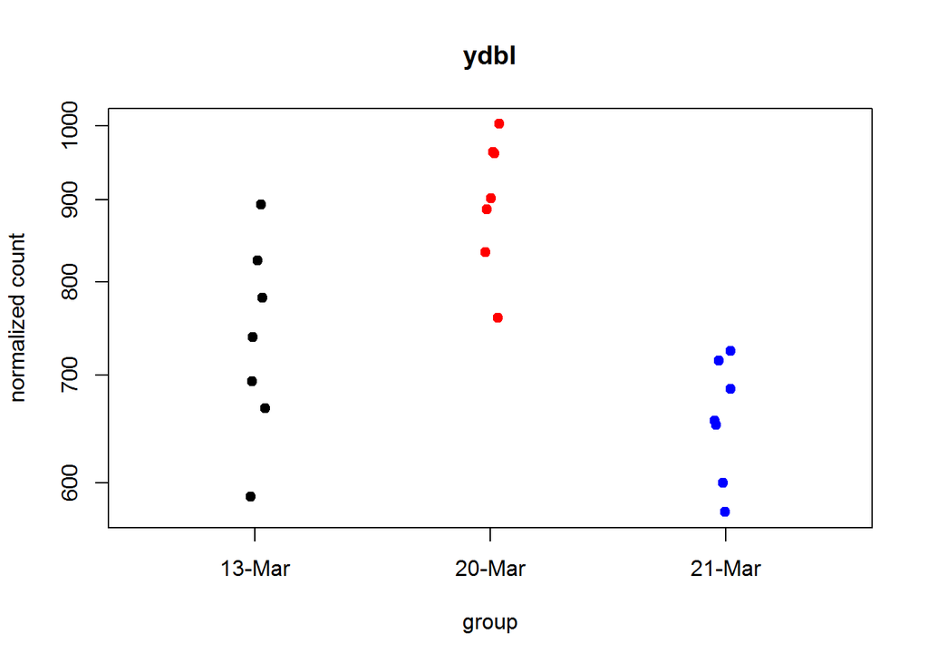

- **Overall, this suggests that most of the expression variance in this dataset is due to slightly different growth rates on different days, and differences in the OD when the cultures were harvested.**
  - ydbI, which is of unknown function, may be transcriptionally-sensitive to metabolic rate

#### 3.2 DEGs underlying Poisson Clustering:

The samp3 file includes a factor named “cluster” based on the groups defined by Poisson clustering this group (see `Rock2-DeSeq-walkthrough_in_markdown`), which are marked and labeled in the following image:

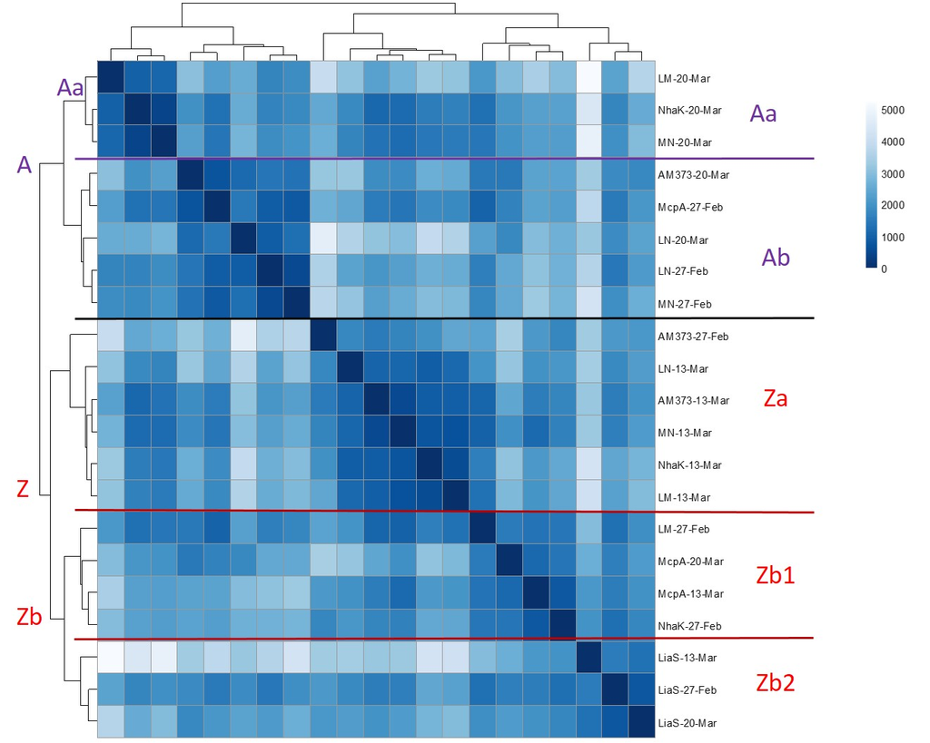

> Note: The clustering was done with a file with the batch names mis-labeled; 27-Feb = 13-Mar, 13-Mar = Mar20, Mar20 = Mar21;

Most 20-Mar samples (13-Mar in figure) and the LiaS-single KO strains all fall in the Z-group, suggesting this group may can generally be characterized as having slower growth than the A-clusters.

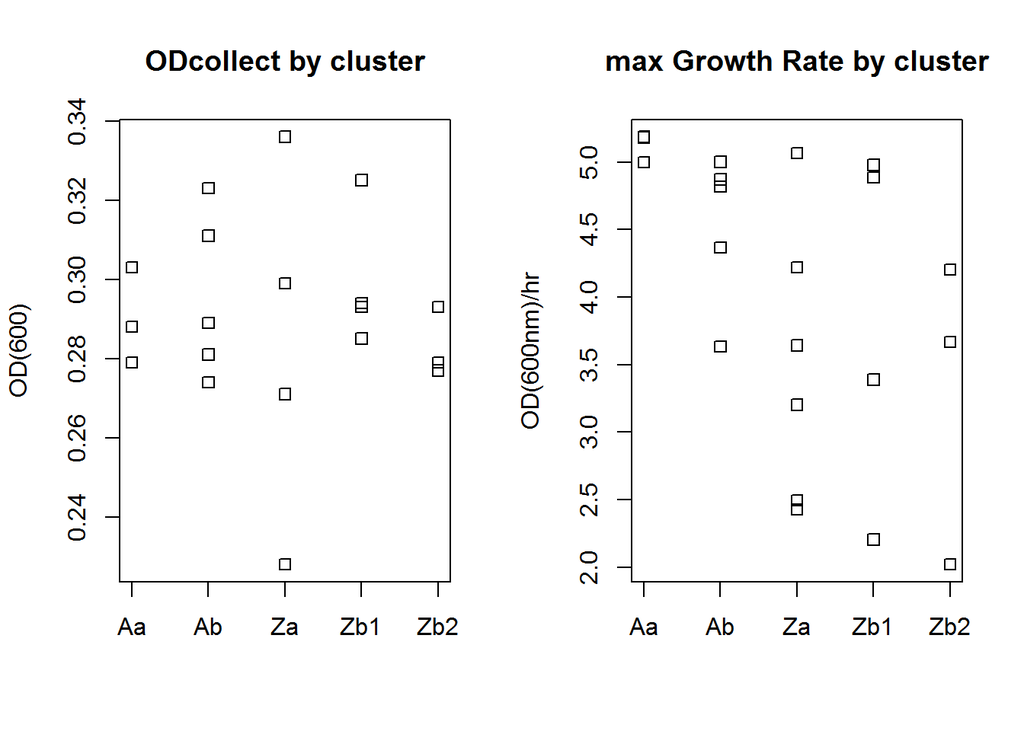

```r
par(mfrow=c(1,2))

stripchart(samp3$avg_OD~samp3$cluster,vertical=TRUE,ylab="OD(600)",main="ODcollect by cluster")
stripchart(samp3$avgVmax~samp3$cluster,vertical=TRUE,ylab="OD(600nm)/hr",main="max Growth Rate by cluster")
```

There is slight correlation between the Poisson cluster and maxGR reached by each sample, in which the “A” clusters generally acheived faster growth rates. However, there seems to be little relationship to OD at which the cells were harvested.

(although there is a lot of overlap in the growth rate ranges spanned by each group)

**DEG analysis of cluster A v Z:** (cluster Z is reference)

Top 5 DEGs:

```r
isAZ<-relevel(as.factor(ifelse(substring(samp3$cluster,1,1)=="A","clustA","clustZ")),ref="clustZ")

sampaz1<-cbind(samp3,isAZ)
resAZ1<-results(DESeq(DESeqDataSetFromMatrix(countData = gtab3,colData = sampaz1,design= ~strain+isAZ)))
AZ1<-top_genes(resAZ1,num=length(which(resAZ1$padj<0.05)))
```

```
## [1] "1104 genes found with padj<0.05"
```

```r
ktab(AZ1[1:5,])
```

|  | Locus.tag | Protein.name | FuncName1 | FuncName2 | FuncName3 | FuncName4 | GoH.sum | ME_name | log10.padj | log2FoldChange | baseMean |
| --- | --- | --- | --- | --- | --- | --- | --- | --- | --- | --- | --- |
| yxbC | BSU39880 | hypothetical protein BSU39880 | Groups of genes | proteins of unknown function | NA | NA | NA | nonphage | -22 | 0.98 | 342 |
| asnH | BSU39920 | asparagine synthetase 2 | Metabolism | amino acid/ nitrogen metabolism | biosynthesis/ acquisition of amino acids | biosynthesis/ acquisition of aspartate/ asparagine | NA | nonphage | -17 | 0.98 | 354 |
| ureA | BSU36660 | urease subunit gamma | Metabolism | amino acid/ nitrogen metabolism | utilization of nitrogen sources other than amino acids | utilization of urea | NA | nonphage | -14 | 1.10 | 157 |
| yxbB | BSU39890 | hypothetical protein BSU39890 | Groups of genes | proteins of unknown function | NA | NA | NA | nonphage | -13 | 1.10 | 232 |
| aslA | BSU39900 | hypothetical protein BSU39900 | Groups of genes | poorly characterized/ putative enzymes | NA | NA | NA | nonphage | -13 | 1.10 | 47 |

Over 1000 DEGs found!

Many top DEGs in the “A” cluster seem to be involved in nitrogen/amino acid metabolism; utilization of urea and biosynthesis of amino acids

Functional categories of DEGs:

```r
print("FuncName1 Categories:")
```

```
## [1] "FuncName1 Categories:"
```

```r
factor_tab(AZ1,"FuncName1")
```

```
##                               FuncName1 DEGs all_in_cat  perc  Up Dwn
## 1                            Metabolism  242        831 0.291 190  52
## 2                    Cellular processes  146        640 0.228  91  55
## 3                Information processing  145        748 0.194  57  88
## 4                       Groups of genes  180       1011 0.178 105  75
## 5 Prophages and mobile genetic elements   43        251 0.171  13  30
## 6                            Lifestyles   70        694 0.101  55  15
## 7                              pred_RNA  225         NA    NA  14 211
## 8                         no assignment   53         NA    NA  NA  NA
```

```r
print("FuncName2 Categories within Metabolism:")
```

```
## [1] "FuncName2 Categories within Metabolism:"
```

```r
factor_tab(AZ1[which(AZ1$FuncName1=="Metabolism"),],"FuncName2")
```

```
##                              FuncName2 DEGs all_in_cat  perc Up Dwn
## 1      amino acid/ nitrogen metabolism   77        179 0.430 70   7
## 2                nucleotide metabolism   26         89 0.292  4  22
## 3        additional metabolic pathways   58        202 0.287 52   6
## 4                    carbon metabolism   51        199 0.256 41  10
## 5 electron transport and ATP synthesis   19         93 0.204 17   2
## 6                     lipid metabolism   11         69 0.159  6   5
```

```r
print("FuncName2 Categories within Cellular processes:")
```

```
## [1] "FuncName2 Categories within Cellular processes:"
```

```r
factor_tab(AZ1[which(AZ1$FuncName1=="Cellular processes"),],"FuncName2")
```

```
##                         FuncName2 DEGs all_in_cat  perc Up Dwn
## 1 cell envelope and cell division   49        186 0.263 27  22
## 2                    transporters   94        430 0.219 62  32
## 3                     homeostasis    3         24 0.125  2   1
```

```r
print("FuncName2 Categories within Information Processing:")
```

```
## [1] "FuncName2 Categories within Information Processing:"
```

```r
factor_tab(AZ1[which(AZ1$FuncName1=="Information processing"),],"FuncName2")
```

```
##                                         FuncName2 DEGs all_in_cat  perc Up Dwn
## 1                   RNA synthesis and degradation   13         53 0.245  6   7
## 2 protein synthesis, modification and degradation   71        320 0.222 24  47
## 3                                        genetics   31        171 0.181 11  20
## 4                   regulation of gene expression   30        204 0.147 16  14
```

```r
factor_tab(AZ1[which(AZ1$FuncName2=="exponential and early post-exponential lifestyles"),],"FuncName3")
```

```
##                 FuncName3 DEGs all_in_cat   perc Up Dwn
## 1 motility and chemotaxis   16         57 0.2810 14   2
## 2       biofilm formation    1         24 0.0417  0   1
```

- Functional analysis basically re-interates that the group “A” clusters have increased metabolism, related to increased amino acid/nitrogen and carbon metabolism, electron transport, and expression of stress response genes. Also have increased expression of many motility and chemotaxis genes.

**GoH analysis:**

GoH network genes among DEGs: 24

Many GoH genes have cluster-based variation in expression, but their discovery at this level of analysis may indicate that they respond to batch effects rather than to the induced genetic perturbation / that they are physilogically important rather than that they contribute to explaining any effects of the induced deletions

However, whether these genes form a cluster within the GoH network could be further investigated.

GoH Hubs found:

|  | Locus.tag | Protein.name | FuncName1 | FuncName2 | FuncName3 | FuncName4 | GoH.sum | ME_name | log10.padj | log2FoldChange | baseMean |
| --- | --- | --- | --- | --- | --- | --- | --- | --- | --- | --- | --- |
| xhlA | BSU12790 | phage-like element PBSX protein XhlA | Prophages and mobile genetic elements | prophages | PBSX prophage | NA | GoH Hub, 22 genes- cssS | PBSX prophage | -3.7 | -0.78 | 308 |
| ydbI | BSU04480 | hypothetical protein BSU04480 | Groups of genes | membrane proteins | NA | NA | GoH Hub, 10 genes | nonphage | -3.7 | -0.38 | 766 |
| smc | BSU15940 | chromosome partition protein Smc | Information processing | genetics | DNA condensation/ segregation | NA | GoH Hub, 12 genes- cssS | nonphage | -2.4 | -0.23 | 4015 |
| ppsC | BSU18320 | plipastatin synthase subunit C | Metabolism | additional metabolic pathways | miscellaneous metabolic pathways | biosynthesis of antibacterial compounds | GoH Hub, 11 genes- cssS | nonphage | -1.9 | 0.43 | 1639 |

All GoH Genes found:

|  | Locus.tag | Protein.name | FuncName1 | FuncName2 | FuncName3 | FuncName4 | GoH.sum | ME_name | log10.padj | log2FoldChange | baseMean |
| --- | --- | --- | --- | --- | --- | --- | --- | --- | --- | --- | --- |
| albF | BSU37420 | zinc protease AlbF | Metabolism | additional metabolic pathways | miscellaneous metabolic pathways | biosynthesis of antibacterial compounds | GoH gene, 6 genes | nonphage | -6.0 | 0.90 | 141 |
| scpA | BSU23220 | segregation and condensation protein A | Information processing | genetics | DNA condensation/ segregation | NA | GoH gene, 2 genes | nonphage | -4.3 | -0.43 | 924 |
| yvcD | BSU34810 | TPR repeat-containing protein YvcD | Groups of genes | proteins of unknown function | NA | NA | GoH gene, 1 genes | nonphage | -3.9 | -0.28 | 1264 |
| menA | BSU38490 | 1,4-dihydroxy-2-naphthoate octaprenyltransferase | Metabolism | additional metabolic pathways | biosynthesis of cofactors | biosynthesis of menaquinone | GoH gene, 1 genes | nonphage | -3.8 | -0.32 | 1493 |
| xhlA | BSU12790 | phage-like element PBSX protein XhlA | Prophages and mobile genetic elements | prophages | PBSX prophage | NA | GoH Hub, 22 genes- cssS | PBSX prophage | -3.7 | -0.78 | 308 |
| ydbI | BSU04480 | hypothetical protein BSU04480 | Groups of genes | membrane proteins | NA | NA | GoH Hub, 10 genes | nonphage | -3.7 | -0.38 | 766 |
| yczI | BSU04120 | hypothetical protein BSU04120 | Groups of genes | membrane proteins | NA | NA | GoH gene, 6 genes | nonphage | -2.9 | -0.56 | 105 |
| yvcB | BSU34840 | hypothetical protein BSU34840 | Groups of genes | proteins of unknown function | NA | NA | GoH gene, 1 genes | nonphage | -2.6 | -0.35 | 6237 |
| pksJ | BSU17180 | polyketide synthase PksJ | Metabolism | additional metabolic pathways | miscellaneous metabolic pathways | biosynthesis of antibacterial compounds | GoH gene, 6 genes- cssS | nonphage | -2.5 | 0.54 | 7915 |
| pepF | BSU11540 | oligoendopeptidase F | Information processing | regulation of gene expression | phosphorelay | NA | GoH gene, 1 genes | nonphage | -2.5 | 0.28 | 4624 |
| divIB | BSU15240 | cell division protein DivIB | Cellular processes | cell envelope and cell division | cell division | NA | GoH gene, 9 genes- cssS | nonphage | -2.4 | -0.33 | 1138 |
| smc | BSU15940 | chromosome partition protein Smc | Information processing | genetics | DNA condensation/ segregation | NA | GoH Hub, 12 genes- cssS | nonphage | -2.4 | -0.23 | 4015 |
| yceE | BSU02910 | hypothetical protein BSU02910 | Lifestyles | coping with stress | general stress proteins (controlled by SigB) | NA | GoH gene, 1 genes | nonphage | -2.4 | 0.31 | 840 |
| xseA | BSU24300 | exodeoxyribonuclease 7 large subunit | Information processing | genetics | genetics/ other/ based on similarity | NA | GoH gene, 3 genes | nonphage | -2.3 | -0.28 | 754 |
| cheA | BSU16430 | chemotaxis protein CheA | Information processing | protein synthesis, modification and degradation | protein modification | protein kinases | GoH gene, 2 genes | nonphage | -2.3 | 0.49 | 5393 |
| yczC | BSU02710 | hypothetical protein BSU02710 | Groups of genes | membrane proteins | NA | NA | GoH gene, 2 genes | nonphage | -2.1 | -0.40 | 601 |
| ptsH | BSU13900 | phosphocarrier protein HPr | Cellular processes | transporters | phosphotransferase systems | NA | GoH gene, 1 genes | nonphage | -2.1 | 0.25 | 6660 |
| yhcR | BSU09190 | endonuclease | Metabolism | nucleotide metabolism | biosynthesis/ acquisition of nucleotides | biosynthesis/ acquisition of nucleotides/ other | GoH gene, 1 genes- cssS | nonphage | -2.0 | 0.30 | 771 |
| cheD | BSU16460 | chemoreceptor glutamine deamidase CheD | Information processing | protein synthesis, modification and degradation | protein modification | protein deaminase | GoH gene, 1 genes | nonphage | -1.9 | 0.43 | 1364 |
| ppsC | BSU18320 | plipastatin synthase subunit C | Metabolism | additional metabolic pathways | miscellaneous metabolic pathways | biosynthesis of antibacterial compounds | GoH Hub, 11 genes- cssS | nonphage | -1.9 | 0.43 | 1639 |
| crh | BSU34740 | HPr-like protein Crh | Information processing | regulation of gene expression | transcription factors and their control | control of transcription factor (other than two-component system) | GoH gene, 1 genes | nonphage | -1.9 | 0.31 | 571 |
| purB | BSU06440 | adenylosuccinate lyase | Metabolism | nucleotide metabolism | biosynthesis/ acquisition of nucleotides | biosynthesis/ acquisition of purine nucleotides | GoH gene, 1 genes | nonphage | -1.9 | -0.45 | 795 |
| lonA | BSU28200 | Lon protease 1 | Information processing | protein synthesis, modification and degradation | proteolysis | NA | GoH gene, 1 genes | nonphage | -1.6 | 0.14 | 3778 |
| ftsW | BSU14850 | lipid II flippase FtsW | Cellular processes | cell envelope and cell division | cell division | NA | GoH gene, 5 genes | nonphage | -1.4 | 0.21 | 1162 |